# SEACAR Nekton Analysis: Species Richness

Last compiled on 15 July, 2026

# Important Notes

The purpose of this script is to determine species richness by gear type and size, create managed area statistics, generate plots, and create reports in pdf and Word document form for Nekton data.

These scripts were created by J.E. Panzik (jepanzik@usf.edu) for SEACAR. Updated by T.G. Hill (Tyler.Hill@FloridaDEP.gov).

All scripts and outputs can be found on the SEACAR GitHub repository:

https://github.com/FloridaSEACAR/SEACAR_Trend_Analyses

This markdown file is designed to be compiled by Nekton_Plot_Render.R (https://github.com/FloridaSEACAR/SEACAR_Trend_Analyses/blob/main/Nekton/Nekton_Plot_Render.R).

Details on the determination of catch per unit effort can be found in the document [SEACAR Nekton catch per unit effort.pdf](https://github.com/FloridaSEACAR/SEACAR_Trend_Analyses/blob/main/Nekton/SEACAR%20Nekton%20catch%20per%20unit%20effort.pdf) (https://github.com/FloridaSEACAR/SEACAR_Trend_Analyses/blob/main/Nekton/SEACAR%20Nekton%20catch%20per%20unit%20effort.pdf).

# Nekton Species Richness

## Apalachicola Bay Aquatic Preserve

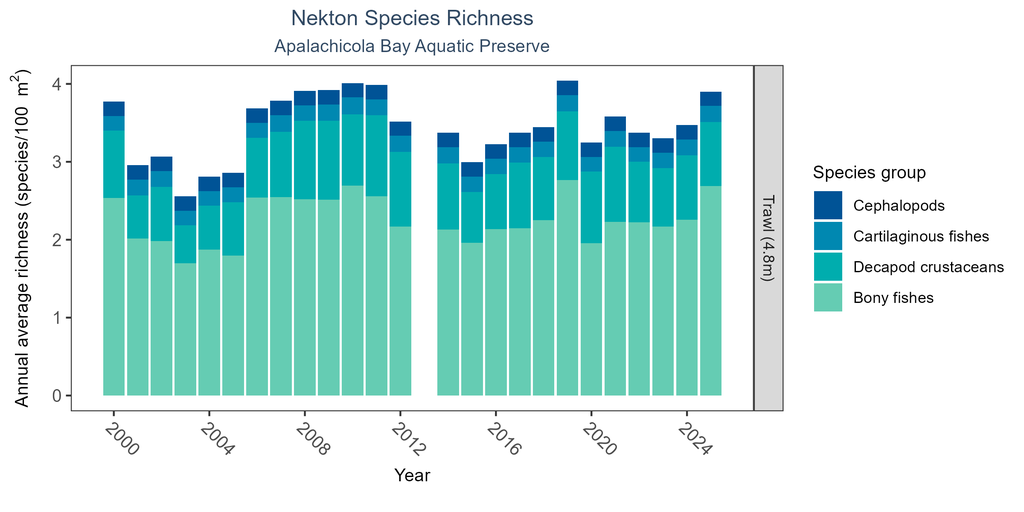

Bar graph(s) of annual average nekton richness over time for species groups occurring in at least 1% of samples. The bar colors represent species groups including bony fishes, cartilaginous fishes, decapod crustaceans (e.g., shrimps, crabs, and lobsters), and cephalopods (e.g., squid). Gear types and sizes are indicated in the panel label.

Nekton Species Richness - Apalachicola Bay Aquatic Preserve

| GearType | GearSize-m | N-Years | EarliestYear | LatestYear | N-Data | Min | Max | Median | Mean | StDev | Year-MinRichness | Year-MaxRichness |
| --- | --- | --- | --- | --- | --- | --- | --- | --- | --- | --- | --- | --- |
| Trawl | 4.8 | 25 | 2000 | 2025 | 5054 | 0.19 | 5.56 | 0.74 | 1.13 | 1.05 | 2015 | 2010 |

The median annual number of taxa was 0.74 based on 5,054 observations collected by 4.8-meter trawl between 2000 and 2025.

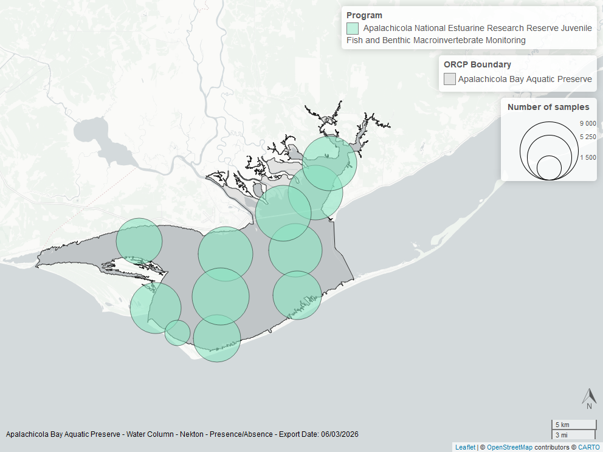

## Apalachicola National Estuarine Research Reserve

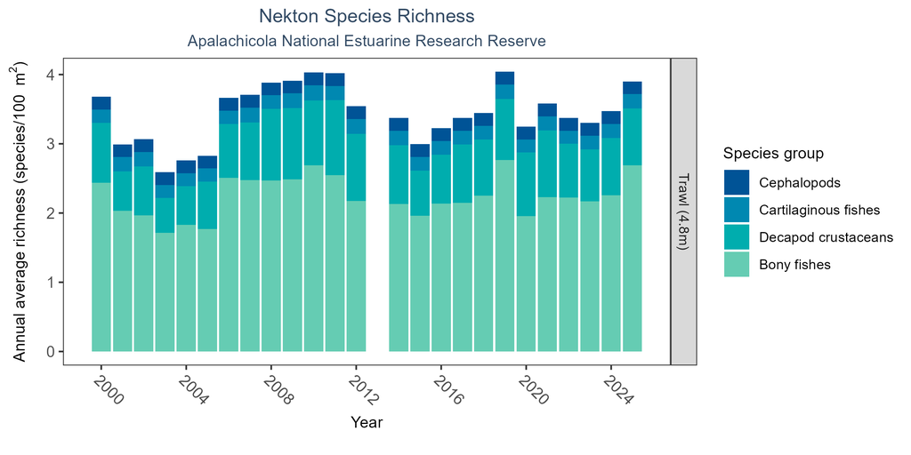

Bar graph(s) of annual average nekton richness over time for species groups occurring in at least 1% of samples. The bar colors represent species groups including bony fishes, cartilaginous fishes, decapod crustaceans (e.g., shrimps, crabs, and lobsters), and cephalopods (e.g., squid). Gear types and sizes are indicated in the panel label.

Nekton Species Richness - Apalachicola National Estuarine Research Reserve

| GearType | GearSize-m | N-Years | EarliestYear | LatestYear | N-Data | Min | Max | Median | Mean | StDev | Year-MinRichness | Year-MaxRichness |
| --- | --- | --- | --- | --- | --- | --- | --- | --- | --- | --- | --- | --- |
| Trawl | 4.8 | 25 | 2000 | 2025 | 5772 | 0.19 | 5.93 | 0.74 | 1.13 | 1.06 | 2015 | 2010 |

The median annual number of taxa was 0.74 based on 5,772 observations collected by 4.8-meter trawl between 2000 and 2025.

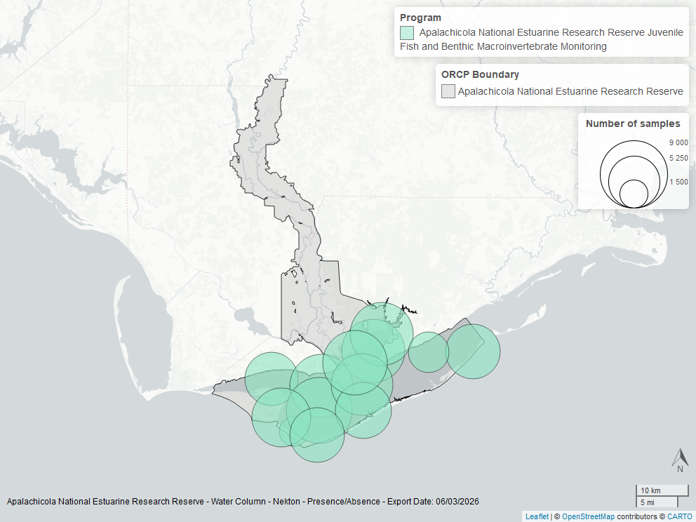

## Boca Ciega Bay Aquatic Preserve

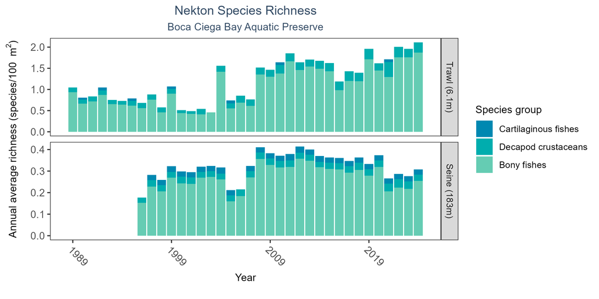

Bar graph(s) of annual average nekton richness over time for species groups occurring in at least 1% of samples. The bar colors represent species groups including bony fishes, cartilaginous fishes, decapod crustaceans (e.g., shrimps, crabs, and lobsters), and cephalopods (e.g., squid). Gear types and sizes are indicated in the panel label.

Nekton Species Richness - Boca Ciega Bay Aquatic Preserve

| GearType | GearSize-m | N-Years | EarliestYear | LatestYear | N-Data | Min | Max | Median | Mean | StDev | Year-MinRichness | Year-MaxRichness |
| --- | --- | --- | --- | --- | --- | --- | --- | --- | --- | --- | --- | --- |
| Trawl | 6.1 | 36 | 1989 | 2024 | 1830 | 0.04 | 3.78 | 0.45 | 0.77 | 0.81 | 2000 | 2022 |
| Seine | 183.0 | 29 | 1996 | 2024 | 1655 | 0.02 | 0.85 | 0.15 | 0.19 | 0.17 | 2005 | 2008 |

The median annual number of taxa was 0.15 based on 1,655 observations collected by 183-meter seine between 1996 and 2024, and the median annual number of taxa was 0.45 based on 1,830 observations collected by 6.1-meter trawl between 1989 and 2024.

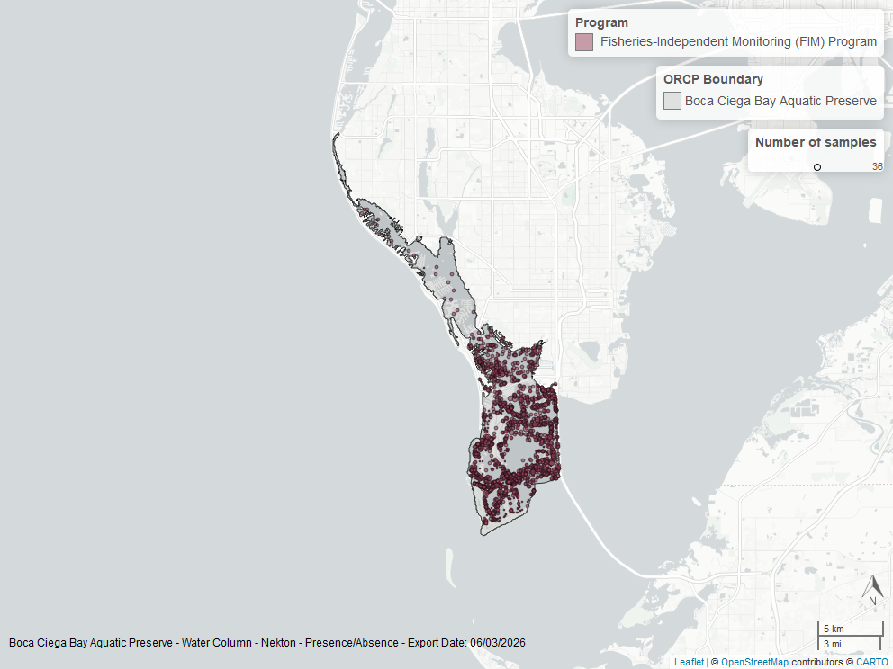

## Cape Romano-Ten Thousand Islands Aquatic Preserve

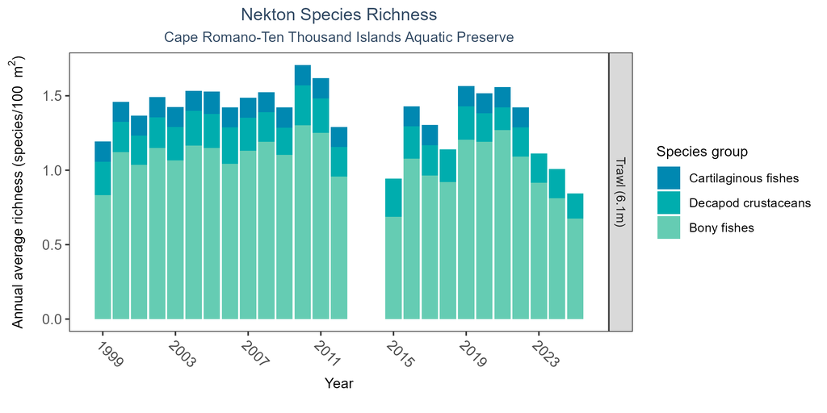

Bar graph(s) of annual average nekton richness over time for species groups occurring in at least 1% of samples. The bar colors represent species groups including bony fishes, cartilaginous fishes, decapod crustaceans (e.g., shrimps, crabs, and lobsters), and cephalopods (e.g., squid). Gear types and sizes are indicated in the panel label.

Nekton Species Richness - Cape Romano-Ten Thousand Islands Aquatic Preserve

| GearType | GearSize-m | N-Years | EarliestYear | LatestYear | N-Data | Min | Max | Median | Mean | StDev | Year-MinRichness | Year-MaxRichness |
| --- | --- | --- | --- | --- | --- | --- | --- | --- | --- | --- | --- | --- |
| Trawl | 6.1 | 25 | 1999 | 2025 | 6283 | 0.13 | 3.24 | 0.4 | 0.65 | 0.56 | 2025 | 2010 |

The median annual number of taxa was 0.40 based on 6,283 observations collected by 6.1-meter trawl between 1999 and 2025.

[figure not shown]

## Cockroach Bay Aquatic Preserve

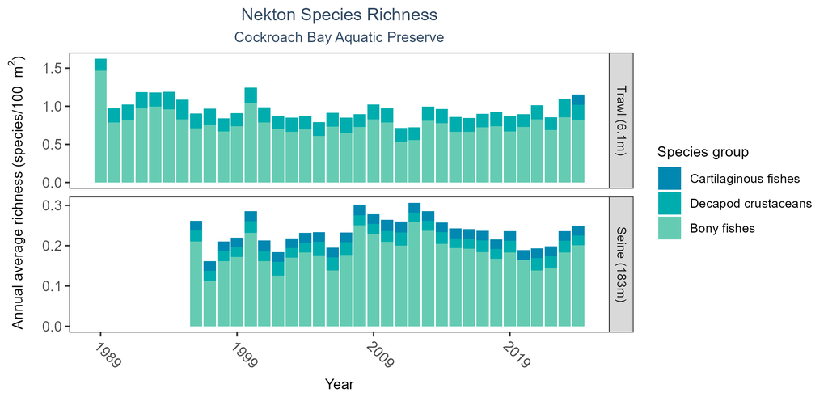

Bar graph(s) of annual average nekton richness over time for species groups occurring in at least 1% of samples. The bar colors represent species groups including bony fishes, cartilaginous fishes, decapod crustaceans (e.g., shrimps, crabs, and lobsters), and cephalopods (e.g., squid). Gear types and sizes are indicated in the panel label.

Nekton Species Richness - Cockroach Bay Aquatic Preserve

| GearType | GearSize-m | N-Years | EarliestYear | LatestYear | N-Data | Min | Max | Median | Mean | StDev | Year-MinRichness | Year-MaxRichness |
| --- | --- | --- | --- | --- | --- | --- | --- | --- | --- | --- | --- | --- |
| Trawl | 6.1 | 36 | 1989 | 2024 | 2968 | 0.07 | 3.30 | 0.3 | 0.50 | 0.45 | 2011 | 1989 |
| Seine | 183.0 | 29 | 1996 | 2024 | 841 | 0.02 | 0.63 | 0.1 | 0.13 | 0.11 | 1997 | 2012 |

The median annual number of taxa was 0.10 based on 841 observations collected by 183-meter seine between 1996 and 2024, and the median annual number of taxa was 0.30 based on 2,968 observations collected by 6.1-meter trawl between 1989 and 2024.

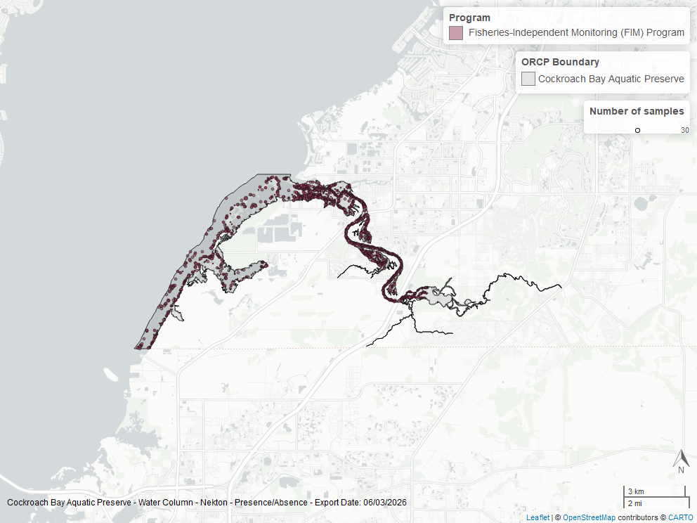

## Lemon Bay Aquatic Preserve

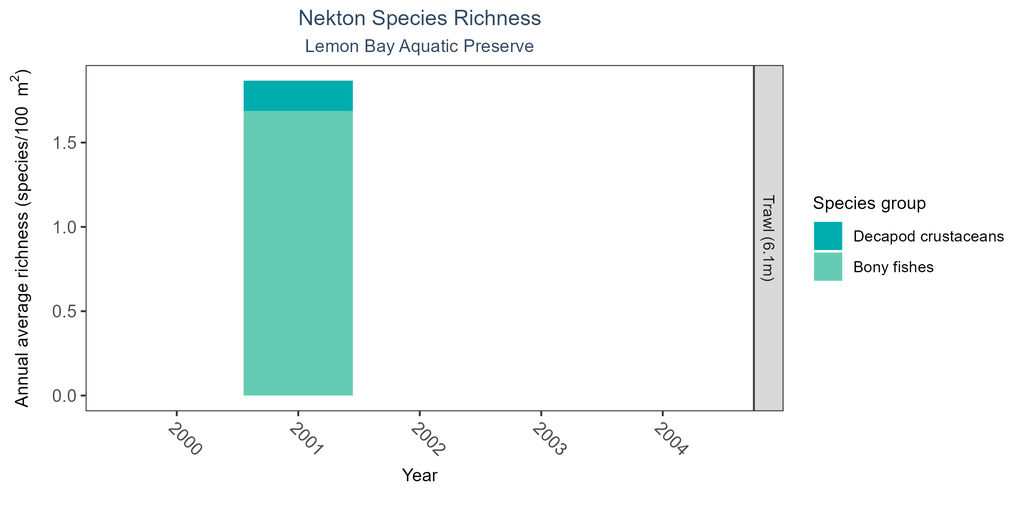

Bar graph(s) of annual average nekton richness over time for species groups occurring in at least 1% of samples. The bar colors represent species groups including bony fishes, cartilaginous fishes, decapod crustaceans (e.g., shrimps, crabs, and lobsters), and cephalopods (e.g., squid). Gear types and sizes are indicated in the panel label.

Nekton Species Richness - Lemon Bay Aquatic Preserve

| GearType | GearSize-m | N-Years | EarliestYear | LatestYear | N-Data | Min | Max | Median | Mean | StDev | Year-MinRichness | Year-MaxRichness |
| --- | --- | --- | --- | --- | --- | --- | --- | --- | --- | --- | --- | --- |
| Trawl | 6.1 | 1 | 2001 | 2001 | 6 | 0.13 | 2.02 | 0.74 | 0.93 | 0.87 | 2001 | 2001 |

The median annual number of taxa was 0.74 based on 6 observations collected by 6.1-meter trawl between 2001 and 2001.

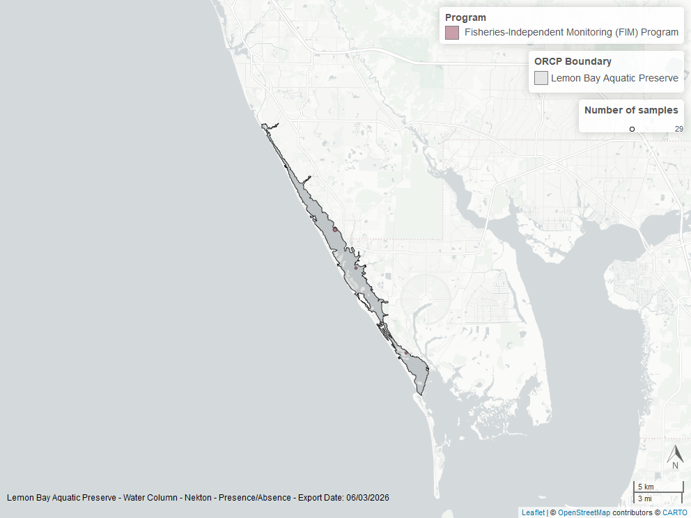

## Pinellas County Aquatic Preserve

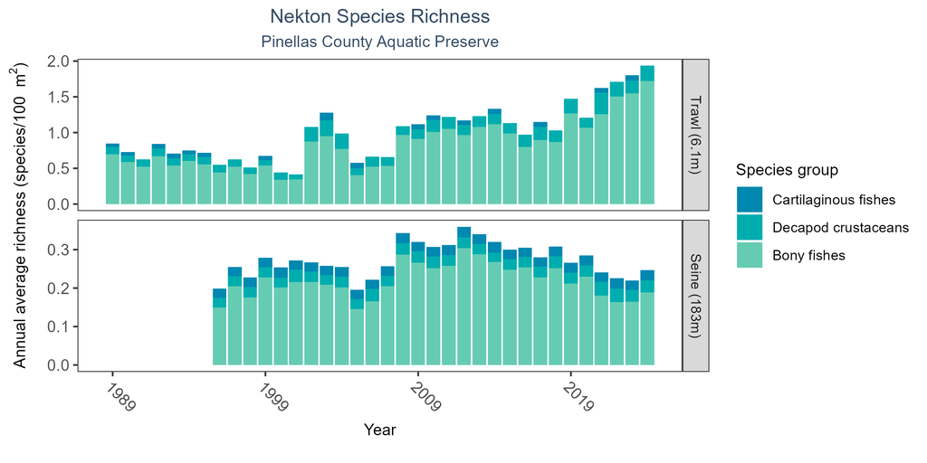

Bar graph(s) of annual average nekton richness over time for species groups occurring in at least 1% of samples. The bar colors represent species groups including bony fishes, cartilaginous fishes, decapod crustaceans (e.g., shrimps, crabs, and lobsters), and cephalopods (e.g., squid). Gear types and sizes are indicated in the panel label.

Nekton Species Richness - Pinellas County Aquatic Preserve

| GearType | GearSize-m | N-Years | EarliestYear | LatestYear | N-Data | Min | Max | Median | Mean | StDev | Year-MinRichness | Year-MaxRichness |
| --- | --- | --- | --- | --- | --- | --- | --- | --- | --- | --- | --- | --- |
| Trawl | 6.1 | 36 | 1989 | 2024 | 5561 | 0.03 | 4.86 | 0.3 | 0.57 | 0.66 | 2001 | 2022 |
| Seine | 183.0 | 29 | 1996 | 2024 | 4688 | 0.02 | 0.85 | 0.1 | 0.15 | 0.15 | 2005 | 2013 |

The median annual number of taxa was 0.10 based on 4,688 observations collected by 183-meter seine between 1996 and 2024, and the median annual number of taxa was 0.30 based on 5,561 observations collected by 6.1-meter trawl between 1989 and 2024.

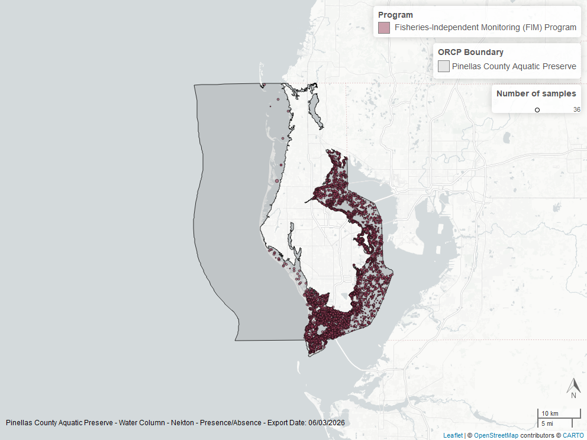

## Rookery Bay Aquatic Preserve

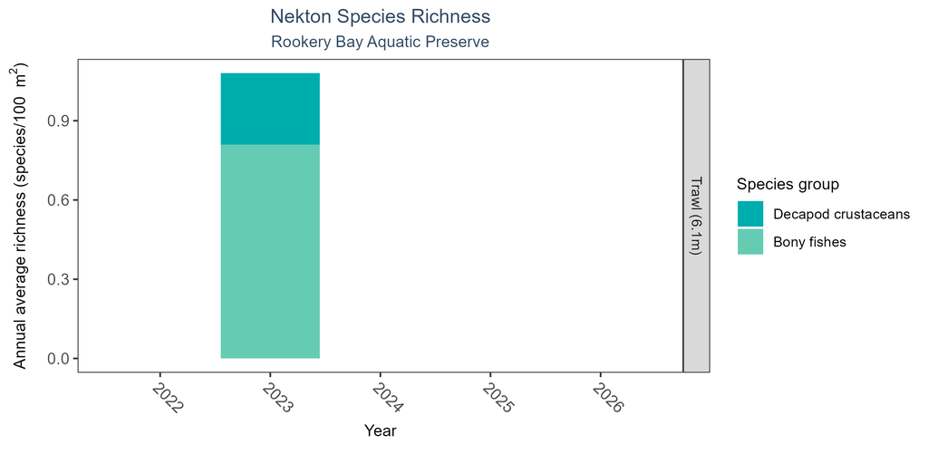

Bar graph(s) of annual average nekton richness over time for species groups occurring in at least 1% of samples. The bar colors represent species groups including bony fishes, cartilaginous fishes, decapod crustaceans (e.g., shrimps, crabs, and lobsters), and cephalopods (e.g., squid). Gear types and sizes are indicated in the panel label.

Nekton Species Richness - Rookery Bay Aquatic Preserve

| GearType | GearSize-m | N-Years | EarliestYear | LatestYear | N-Data | Min | Max | Median | Mean | StDev | Year-MinRichness | Year-MaxRichness |
| --- | --- | --- | --- | --- | --- | --- | --- | --- | --- | --- | --- | --- |
| Trawl | 6.1 | 1 | 2023 | 2023 | 2 | 0.27 | 0.81 | 0.54 | 0.54 | 0.38 | 2023 | 2023 |

The median annual number of taxa was 0.54 based on 2 observations collected by 6.1-meter trawl between 2023 and 2023.

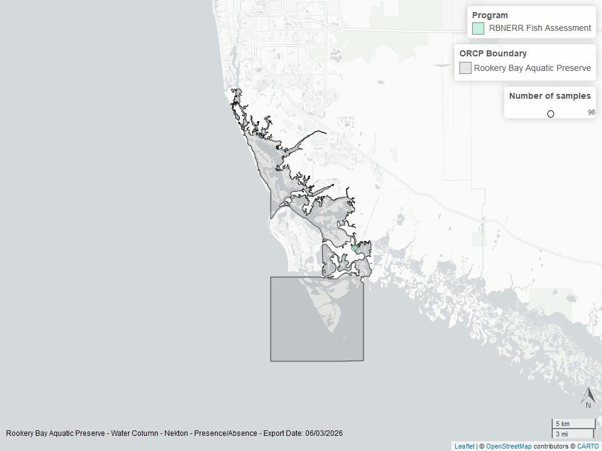

## Rookery Bay National Estuarine Research Reserve

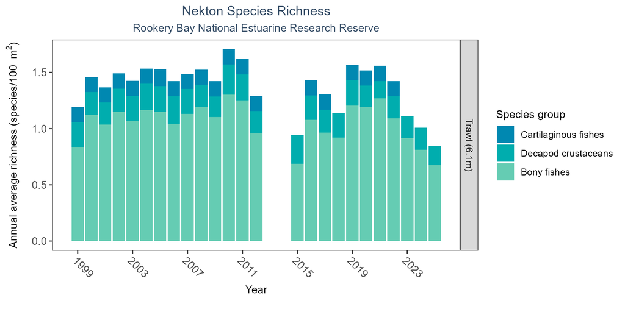

Bar graph(s) of annual average nekton richness over time for species groups occurring in at least 1% of samples. The bar colors represent species groups including bony fishes, cartilaginous fishes, decapod crustaceans (e.g., shrimps, crabs, and lobsters), and cephalopods (e.g., squid). Gear types and sizes are indicated in the panel label.

Nekton Species Richness - Rookery Bay National Estuarine Research Reserve

| GearType | GearSize-m | N-Years | EarliestYear | LatestYear | N-Data | Min | Max | Median | Mean | StDev | Year-MinRichness | Year-MaxRichness |
| --- | --- | --- | --- | --- | --- | --- | --- | --- | --- | --- | --- | --- |
| Trawl | 6.1 | 25 | 1999 | 2025 | 6285 | 0.13 | 3.24 | 0.4 | 0.65 | 0.56 | 2025 | 2010 |

The median annual number of taxa was 0.40 based on 6,285 observations collected by 6.1-meter trawl between 1999 and 2025.

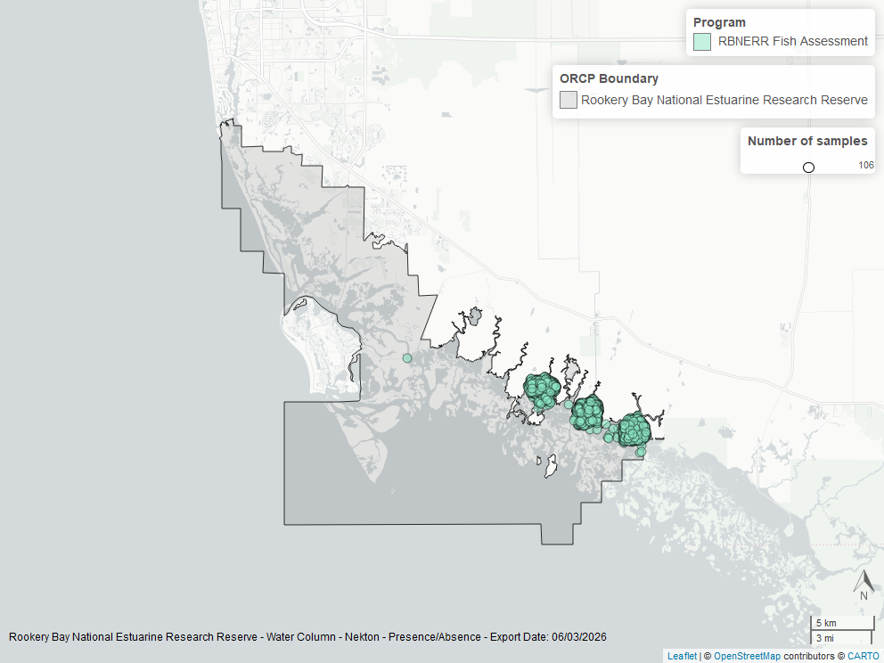

## St. Martins Marsh Aquatic Preserve

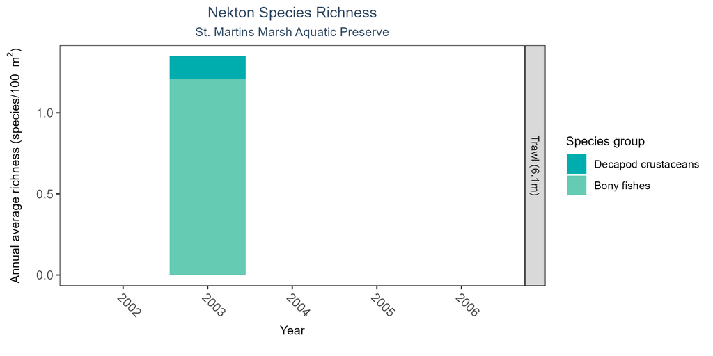

Bar graph(s) of annual average nekton richness over time for species groups occurring in at least 1% of samples. The bar colors represent species groups including bony fishes, cartilaginous fishes, decapod crustaceans (e.g., shrimps, crabs, and lobsters), and cephalopods (e.g., squid). Gear types and sizes are indicated in the panel label.

Nekton Species Richness - St. Martins Marsh Aquatic Preserve

| GearType | GearSize-m | N-Years | EarliestYear | LatestYear | N-Data | Min | Max | Median | Mean | StDev | Year-MinRichness | Year-MaxRichness |
| --- | --- | --- | --- | --- | --- | --- | --- | --- | --- | --- | --- | --- |
| Trawl | 6.1 | 1 | 2003 | 2003 | 2 | 0.14 | 1.21 | 0.67 | 0.67 | 0.75 | 2003 | 2003 |

The median annual number of taxa was 0.67 based on 2 observations collected by 6.1-meter trawl between 2003 and 2003.

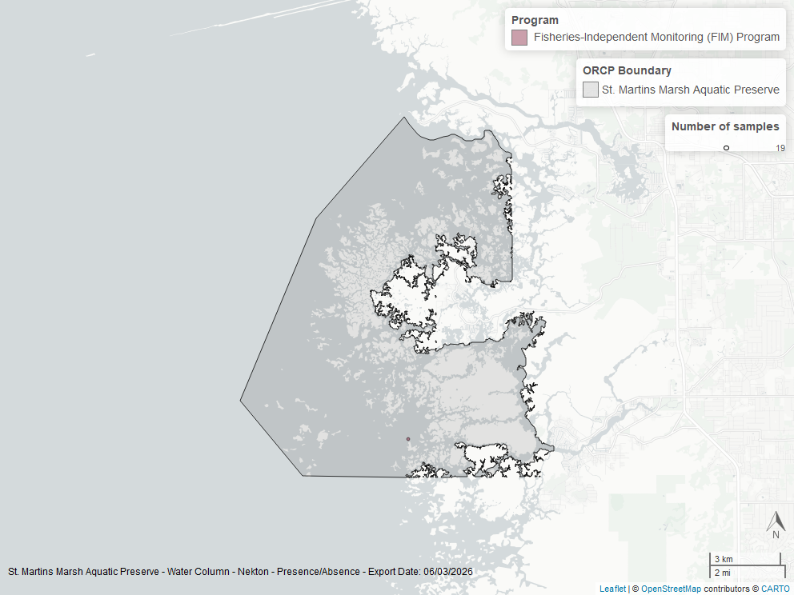

## Terra Ceia Aquatic Preserve

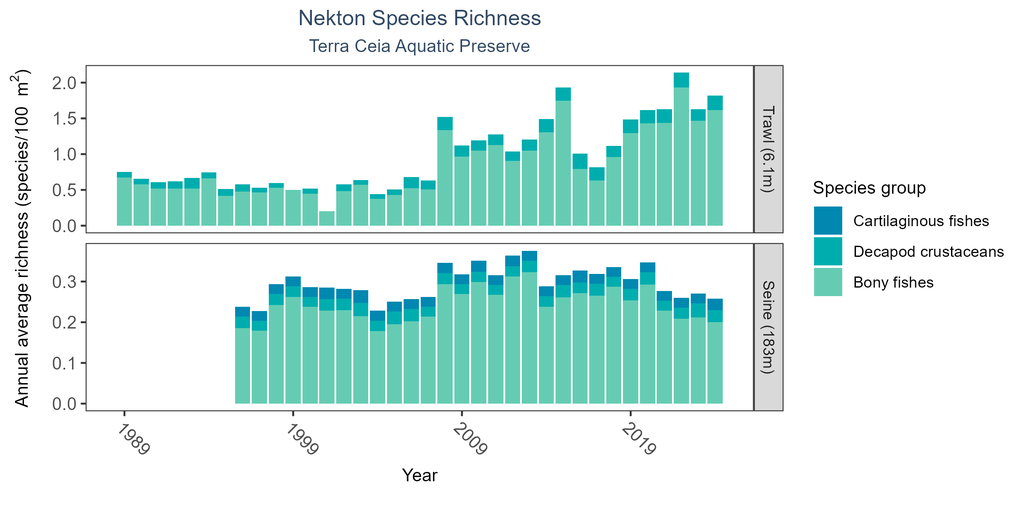

Bar graph(s) of annual average nekton richness over time for species groups occurring in at least 1% of samples. The bar colors represent species groups including bony fishes, cartilaginous fishes, decapod crustaceans (e.g., shrimps, crabs, and lobsters), and cephalopods (e.g., squid). Gear types and sizes are indicated in the panel label.

Nekton Species Richness - Terra Ceia Aquatic Preserve

| GearType | GearSize-m | N-Years | EarliestYear | LatestYear | N-Data | Min | Max | Median | Mean | StDev | Year-MinRichness | Year-MaxRichness |
| --- | --- | --- | --- | --- | --- | --- | --- | --- | --- | --- | --- | --- |
| Trawl | 6.1 | 36 | 1989 | 2024 | 1382 | 0.04 | 3.88 | 0.32 | 0.65 | 0.75 | 2001 | 2022 |
| Seine | 183.0 | 29 | 1996 | 2024 | 1543 | 0.02 | 0.66 | 0.17 | 0.17 | 0.14 | 2004 | 2012 |

The median annual number of taxa was 0.17 based on 1,543 observations collected by 183-meter seine between 1996 and 2024, and the median annual number of taxa was 0.32 based on 1,382 observations collected by 6.1-meter trawl between 1989 and 2024.

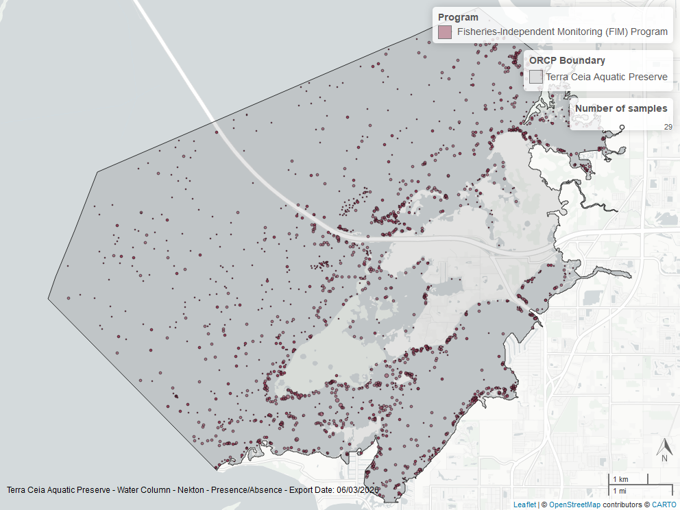

# Libraries and Settings

Loads libraries used in the script. The inclusion of `scipen` option limits how frequently R defaults to scientific notation. Sets default settings for displaying warning and messages in created document, and sets figure dpi.

```r
library(knitr)
library(data.table)
library(dplyr)
library(lubridate)
library(ggplot2)
library(scales)
library(tidyr)
library(gridExtra)
#library(tidyverse)
library(ggpubr)
library(scales)
library(glue)
options(scipen=999)
knitr::opts_chunk$set(
   warning=FALSE,
   message=FALSE,
   dpi=200,
   fig.pos = 'H'
   )
```

# File Import

Imports file that is determined in the Nekton_SpeciesRichness_ReportRender.R script.

The command `fread` is used because of its improved speed while handling large data files. Only columns that are used by the script are imported from the file, and are designated in the `select` input.

The script then gets the name of the parameter as it appears in the data file and units of the parameter.

The latest version of Nekton data is available at: https://usf.box.com/s/35sn0n0lrrxi9dtkik030nozbvnj9dyj

The file being used for the analysis is: **All_NEKTON_Parameters-2026-Jun-04.txt**

```r
#Import data from nekton file
data <- fread(file_in, sep="|", header=TRUE, stringsAsFactors=FALSE,
              na.strings=c("NULL"))

cat(paste("The data file used is:", file_short, sep="\n"))
```

# Data Filtering

Documentation on database filtering is provided here: [SEACAR Documentation- Analysis Filters and Calculations.pdf](https://github.com/FloridaSEACAR/SEACAR_Trend_Analyses/blob/main/SEACAR%20Documentation%20-%20Analysis%20Filters%20and%20Calculations.pdf) (https://github.com/FloridaSEACAR/SEACAR_Trend_Analyses/blob/main/SEACAR%20Documentation%20-%20Analysis%20Filters%20and%20Calculations.pdf).

Imported data is initially filtered to only contain the parameter of interest.

The other filtering performed by the script at this point removes rows that are missing values for `ResultValue` and `EffortCorrection_100m2`, and removes any `EffortCorrection_100m2` that is 0 because it will cause an infinite number when determining Species Richness.

A group of unique `ManagedAreaName`, `ProgramID`, `ProgramName`, `ProgramLocationID`, `SampleDate`, and `GearSize_m` are being considered a “reference” for measurement. For each “reference”, the number of observed species is summed and then divided by the `EffortCorrection_100m2`to determine the Species Richness per 100 square meters.

The species richness data is then written to a file. And the list of Managed Areas with observations is stored.

```r
# Filter data for the desired parameter
data <- data[ParameterName==param_name, ]

if(param_name=="Presence/Absence"){
  parameter <- "Species Richness"
}
# Makes sure EffortCorrection is numeric value
data$EffortCorrection_100m2 <- as.numeric(data$EffortCorrection_100m2)

# Remove any data with missing EffortCorrection values
data <- data[!is.na(data$EffortCorrection_100m2),]

# Only keep data that has non-zero EffortCorrection values
data <- data[data$EffortCorrection_100m2!=0,]

# Remove any data with missing ResultValue entries
data <- data[!is.na(data$ResultValue),]

# Create Species Richness values for groups of unique combinations of
# ManagedAreaName, ProgramID, ProgramName, ProgramLocationID, SampleDate,
# GearType, and GearSize_m.
data <- data %>%
  group_by(AreaID, ManagedAreaName, ProgramID, ProgramName, ProgramLocationID,
           SampleDate, GearType, GearSize_m) %>%
  summarise(ParameterName=parameter,
            Year=unique(Year), Month=unique(Month),
            N_Species=sum(ResultValue),
            EffortCorrection_100m2=as.numeric(unique(EffortCorrection_100m2)),
            SpeciesRichness=N_Species/unique(EffortCorrection_100m2),
            .groups = "keep")

# Writes this data that is used by the rest of the script to a text file
fwrite(data, paste0(out_dir,"/Nekton_", param_file, "_UsedData.txt"), sep="|")

# Makes sure SampleDate is being stored as a Date object
data$SampleDate <- as.Date(data$SampleDate)

# Creates a variable with the names of all the managed areas that contain
# species observations
nekton_MA_Include <- unique(data$ManagedAreaName[!is.na(data$N_Species)])

# Puts the managed areas in alphabetical order
nekton_MA_Include <- nekton_MA_Include[order(nekton_MA_Include)]

# Determines the number of managed areas used
n <- length(nekton_MA_Include)
```

# Managed Area Statistics

Gets summary statistics for each managed area. Uses piping from dplyr package to feed into subsequent steps. The following steps are performed:

1. Group data that have the same `ManagedAreaName`, `Year`, `Month`, `GearType`, and `GearSize_m`.
   - Second summary statistics do not use the `Month` grouping and are only for `ManagedAreaName`, `Year`, `GearType`, and `GearSize_m`.
   - Third summary statistics do not use `Year` grouping and are only for `ManagedAreaName`, `Month`, `GearType`, and `GearSize_m`
   - Fourth summary statistics are only grouped based on `ManagedAreaName`, `GearType`, and `GearSize_m`
     - Determines the years that the minimum and maximum species richness occurred
2. For each group, provide the following information: Parameter Name (ParameterName), Number of Entries (N_Data), Lowest Value (Min), Largest Value (Max), Median, Mean, Standard Deviation, and a list of all Program IDs included in these measurements.
3. Sort the data in ascending (A to Z and 0 to 9) order based on `ManagedAreaName` then `Year` then `Month`
4. Write summary stats to a pipe-delimited .txt file in the output directory
   - [Nekton Output Files in SEACAR GitHub](https://github.com/FloridaSEACAR/SEACAR_Trend_Analyses/tree/main/Nekton/output) (https://github.com/FloridaSEACAR/SEACAR_Trend_Analyses/tree/main/Nekton/output)

```r
# Create summary statistics for each managed area based on Year and Month
# intervals, and each gear type and size.
MA_YM_Stats <- data %>%
  group_by(AreaID, ManagedAreaName, Year, Month, GearType, GearSize_m) %>%
  summarize(ParameterName=parameter,
            N_Data=length(na.omit(SpeciesRichness)),
            Min=min(SpeciesRichness),
            Max=max(SpeciesRichness),
            Median=median(SpeciesRichness),
            Mean=mean(SpeciesRichness),
            StandardDeviation=sd(SpeciesRichness),
            Programs=paste(sort(unique(ProgramName), decreasing=FALSE),
                           collapse=', '),
            ProgramIDs=paste(sort(unique(ProgramID), decreasing=FALSE),
                             collapse=', '),
            .groups = "keep")
# Puts the data in order based on ManagedAreaName, Year, Month, then GearSize
MA_YM_Stats <- as.data.table(MA_YM_Stats[order(MA_YM_Stats$ManagedAreaName,
                                               MA_YM_Stats$Year,
                                               MA_YM_Stats$Month,
                                               MA_YM_Stats$GearSize_m), ])
# Writes summary statistics to file
fwrite(MA_YM_Stats, paste0(out_dir,"/Nekton_", param_file,
                           "_MA_MMYY_Stats.txt"), sep="|")
# Removes variable storing data to improve computer memory
rm(MA_YM_Stats)

# Create summary statistics for each managed area based on Year intervals,
# and each gear type and size.
MA_Y_Stats <- data %>%
  group_by(AreaID, ManagedAreaName, Year, GearType, GearSize_m) %>%
  summarize(ParameterName=parameter,
            N_Data=length(na.omit(SpeciesRichness)),
            Min=min(SpeciesRichness),
            Max=max(SpeciesRichness),
            Median=median(SpeciesRichness),
            Mean=mean(SpeciesRichness),
            StandardDeviation=sd(SpeciesRichness),
            Programs=paste(sort(unique(ProgramName), decreasing=FALSE),
                           collapse=', '),
            ProgramIDs=paste(sort(unique(ProgramID), decreasing=FALSE),
                             collapse=', '),
            .groups = "keep")
# Puts the data in order based on ManagedAreaName, Year, then GearSize
MA_Y_Stats <- as.data.table(MA_Y_Stats[order(MA_Y_Stats$ManagedAreaName,
                                             MA_Y_Stats$Year,
                                             MA_Y_Stats$GearSize_m), ])
# Writes summary statistics to file
fwrite(MA_Y_Stats, paste0(out_dir,"/Nekton_", param_file,
                          "_MA_Yr_Stats.txt"), sep="|")

# Create summary statistics for each managed area based on Month intervals,
# and each gear type and size.
MA_M_Stats <- data %>%
  group_by(AreaID, ManagedAreaName, Month, GearType, GearSize_m) %>%
  summarize(ParameterName=parameter,
            N_Data=length(na.omit(SpeciesRichness)),
            Min=min(SpeciesRichness),
            Max=max(SpeciesRichness),
            Median=median(SpeciesRichness),
            Mean=mean(SpeciesRichness),
            StandardDeviation=sd(SpeciesRichness),
            Programs=paste(sort(unique(ProgramName), decreasing=FALSE),
                           collapse=', '),
            ProgramIDs=paste(sort(unique(ProgramID), decreasing=FALSE),
                             collapse=', '),
            .groups = "keep")
# Puts the data in order based on ManagedAreaName, Month, then GearSize
MA_M_Stats <- as.data.table(MA_M_Stats[order(MA_M_Stats$ManagedAreaName,
                                             MA_M_Stats$Month,
                                             MA_M_Stats$GearSize_m), ])
# Writes summary statistics to file
fwrite(MA_M_Stats, paste0(out_dir,"/Nekton_", param_file,
                          "_MA_Mo_Stats.txt"), sep="|")
# Removes variable storing data to improve computer memory
rm(MA_M_Stats)

# Create summary overall statistics for each managed area based each gear type
# and size.
MA_Ov_Stats <- data %>%
  group_by(AreaID, ManagedAreaName, GearType, GearSize_m) %>%
  summarize(ParameterName=parameter,
            N_Years=length(unique(na.omit(Year))),
            EarliestYear=min(Year),
            LatestYear=max(Year),
            N_Data=length(na.omit(SpeciesRichness)),
            Min=min(SpeciesRichness),
            Max=max(SpeciesRichness),
            Median=median(SpeciesRichness),
            Mean=mean(SpeciesRichness),
            StandardDeviation=sd(SpeciesRichness),
            Programs=paste(sort(unique(ProgramName), decreasing=FALSE),
                           collapse=', '),
            ProgramIDs=paste(sort(unique(ProgramID), decreasing=FALSE),
                             collapse=', '),
            .groups = "keep")
# Puts the data in order based on ManagedAreaName then GearSize
MA_Ov_Stats <- as.data.table(MA_Ov_Stats[order(MA_Ov_Stats$ManagedAreaName,
                                               MA_Ov_Stats$GearSize_m), ])
# Creates Year_MinRichness and Year_MaxRichness columns
MA_Ov_Stats$Year_MinRichness <- NA
MA_Ov_Stats$Year_MaxRichness <- NA

# Loops through each ManagedAreaName, GearType, and GearSize_m.
# determines what year the minimum and maximum species richness occurred
for(m in 1:nrow(MA_Ov_Stats)){
  # Stores ManagedAreaName, GearType, and GearSize_m for this row
  ma <- MA_Ov_Stats$ManagedAreaName[m]
  gear <- MA_Ov_Stats$GearType[m]
  size <- MA_Ov_Stats$GearSize_m[m]
  # Skips to next row if there are no data for this combination
  if(MA_Ov_Stats$N_Data[m]==0){
    next
  }
  # Gets subset of data from MA_Y_Stats (yearly summary stats) with this
  # combination of ManagedAreaName, GearType, and GearSize_m
  ds <- MA_Y_Stats[MA_Y_Stats$ManagedAreaName==ma &
                     MA_Y_Stats$GearType==gear &
                     MA_Y_Stats$GearSize_m==size,]
  # Gets the minimum and maximum Mean (yearly averages)
  min <- min(ds$Mean)
  max <- max(ds$Mean)
  #Determines what years those minimum and maximum values occured
  year_min <- ds$Year[ds$Mean==min]
  year_max <- ds$Year[ds$Mean==max]
  # Stores the occurrence years of the minimum and maximum into the overall
  # stats for this row
  MA_Ov_Stats$Year_MinRichness[m] <- year_min
  MA_Ov_Stats$Year_MaxRichness[m] <- year_max
}
# Replaces blank ProgramIDs with NA (missing values)
MA_Ov_Stats$ProgramIDs <- replace(MA_Ov_Stats$ProgramIDs,
                                  MA_Ov_Stats$ProgramIDs=="", NA)
MA_Ov_Stats$Programs <- replace(MA_Ov_Stats$Programs,
                                MA_Ov_Stats$Programs=="", NA)
# Write overall statistics to file
fwrite(MA_Ov_Stats, paste0(out_dir,"/Nekton_", param_file,
                           "_MA_Overall_Stats.txt"), sep="|")
# Removes entries from the overall statistics that do not have data.
# Based on presence or absence of EarliestYear
MA_Ov_Stats <- MA_Ov_Stats[!is.na(EarliestYear), ]
```

# Appendix I: Managed Area Species Richness

The plots shown here are the species richness for each managed area with a yearly average, separated by gear size.

```r
# Defines standard plot theme: black and white, no major or minor grid lines,
# Arial font. Title is centered, size 12, and blue (hex coded). Subtitle is
# centered, size 10, and blue (hex coded). Legend title is size 10 and the
# legend is left-justified. X-axis title is size 10 and the margins are padded
# at the top and bottom to give more space for angled axis labels. Y-axis title
# is size 10 and margins are padded on the right side to give more space for
# axis labels. Axis labels are size 10 and the x-axis labels are rotated -45
# degrees with a horizontal justification that aligns them with the tick mark
plot_theme <- theme_bw() +
  theme(panel.grid.major = element_blank(),
        panel.grid.minor = element_blank(),
        text=element_text(family="Arial"),
        plot.title=element_text(hjust=0.5, size=12, color="#314963"),
        plot.subtitle=element_text(hjust=0.5, size=10, color="#314963"),
        legend.title=element_text(size=10),
        legend.text = element_text(hjust=0),
        axis.title.x = element_text(size=10, margin = margin(t = 5, r = 0,
                                                             b = 10, l = 0)),
        axis.title.y = element_text(size=10, margin = margin(t = 0, r = 10,
                                                             b = 0, l = 0)),
        axis.text=element_text(size=10),
        axis.text.x=element_text(angle = -45, hjust = 0))

# Color palette for SEACAR
color_palette <- c("#005396", "#0088B1", "#00ADAE", "#65CCB3", "#AEE4C1", "#FDEBA8", "#F8CD6D", "#F5A800", "#F17B00")

# Determine geartype palette and shapes dynamically
# Combine type and size into one label for plots
MA_Y_Stats$GearType_Plot <- paste0(MA_Y_Stats$GearType, " (",
                                   MA_Y_Stats$GearSize_m, " m)")
# Determine unique gear types to create palettes
# gear_types <- unique(MA_Y_Stats$GearType_Plot)
gear_types <- c("Trawl (4.8 m)","Trawl (6.1 m)","Seine (183 m)")
# Trawl = triangle, seine = square
gear_shapes <- c(24,24,22)
# Trawl = #005396, Seine = #00ADAE
gear_colors <- c("#005396","#005396","#00ADAE")
names(gear_colors) <- gear_types
names(gear_shapes) <- gear_types

# Loop that cycles through each managed area with data
if(n==0){
  # Prints a statement if there are no managed areas with appropriate data
  print("There are no monitoring locations that qualify.")
} else {
  for (i in 1:n) {
    ma_i <- nekton_MA_Include[i]
    ma_abrev <- MA_All[ManagedAreaName==ma_i, Abbreviation]
    # Gets data for target managed area
    plot_data <- MA_Y_Stats[ManagedAreaName==ma_i, ]
    # Find values <5% occurrence
    remove_groups <- plot_data %>%
      group_by(SpeciesGroup2) %>%
      reframe(pct = (sum(N_Data) / sum(plot_data$N_Data))*100) %>%
      filter(pct<5) %>% pull(unique(SpeciesGroup2))
    # Filter values <5% occurrence
    plot_data <- plot_data %>% filter(!SpeciesGroup2 %in% remove_groups)

    # Determines most recent year with available data for managed area
    t_max <- max(MA_Ov_Stats[ManagedAreaName==ma_i, LatestYear])
    # Determines earliest recent year with available data for managed area
    t_min <- min(MA_Ov_Stats[ManagedAreaName==ma_i, EarliestYear])
    # Determines how many years of data are present
    t <- t_max-t_min

    # Creates break intervals for plots based on number of years of data
    if(t>=30){
      # Set breaks to every 10 years if more than 30 years of data
      brk <- -10
    }else if(t<30 & t>=10){
      # Set breaks to every 5 years if between 30 and 10 years of data
      brk <- -5
    }else if(t<10 & t>=4){
      # Set breaks to every 2 years if between 10 and 4 years of data
      brk <- -2
    }else if(t<4 & t>=2){
      # Set breaks to every year if between 4 and 2 years of data
      brk <- -1
    }else if(t<2){
      # Set breaks to every year if less than 2 years of data
      brk <- -1
      # Sets t_max to be 1 year greater and t_min to be 1 year lower
      # Forces graph to have at least 3 tick marks
      t_max <- t_max+1
      t_min <- t_min-1
    }
    # Determine range of data values for the managed area
    y_range <- max(plot_data$Mean) - min(plot_data$Mean)

    # Determines lower bound of y-axis based on data range. Set based on
    # relation of data range to minimum value. Designed to set lower boundary
    # to be 10% of the data range below the minimum value
    y_min <- if(min(plot_data$Mean)-(0.1*y_range)<0){
      # If 10% of the data range below the minimum value is less than 0,
      # set as 0
      y_min <- 0
    } else {
      # Otherwise set minimum bound as 10% data range below minimum value
      y_min <- min(plot_data$Mean)-(0.1*y_range)
    }

    # Sets upper bound of y-axis to be 10% of the data range above the
    # maximum value.
    y_max <- max(plot_data$Mean)+(0.1*y_range)

    ## Legend labels - grab list of unique SG2 for this MA
    sp_list <- unique(plot_data$SpeciesGroup2)
    sp_list <- sp_list[order(match(sp_list, names(sg2_palette)))]
    # Create common name labels for legend display
    sp_labels <- sapply(sp_list, function(x){sg_common[[x]]})

    # Creates plot object using plot_data and grouping by the plot gear types.
    # Data is plotted as symbols with connected lines.
    p1 <- ggplot(data=plot_data,
                 aes(fill = SpeciesGroup2, y=Mean, x=Year)) +
      geom_bar(position="stack", stat="identity") +
      facet_wrap(~GearType_Plot,
                 nrow=2, ncol=1,
                 strip.position = "right",
                 scales = "free_y") +
      labs(title="Nekton Species Richness",
           subtitle=ma_i,
           x="Year", y=bquote('Richness (species/100'*~m^{2}*')')) +
      scale_fill_manual(name = "Species group",
                        values = subset(sg2_palette, names(sg2_palette) %in%
                                          unique(plot_data$SpeciesGroup2)),
                        labels = sp_labels) +
      scale_x_continuous(limits = c(t_min-1, t_max+1),
                         breaks = seq(t_max, t_min, brk)) +
      plot_theme
    # Sets file name of plot created
    outname <- paste0("Nekton_", param_file, "_", ma_abrev, ".png")
    # Saves plot as a png image
    png(paste0(out_dir, "/Figures/", outname),
        width = 8,
        height = 4,
        units = "in",
        res = 200)
    print(p1)
    dev.off()

    # Creates a data table object to be shown underneath plots in report
    ResultTable <- MA_Ov_Stats[ManagedAreaName==ma_i, ]
    # Removes location, gear, and parameter information because it is in plot
    # labels
    ResultTable <- ResultTable[,-c("AreaID", "ManagedAreaName",
                                   "ProgramIDs", "Programs", "GearType_Plot",
                                   "ParameterName")]
    # Renames StandardDeviation to StDev to save horizontal space
    ResultTable <- ResultTable %>%
      rename("StDev"="StandardDeviation")
    # Converts all non-integer values to 2 decimal places for space
    ResultTable$Min <- round(ResultTable$Min, digits=2)
    ResultTable$Max <- round(ResultTable$Max, digits=2)
    ResultTable$Median <- round(ResultTable$Median, digits=2)
    ResultTable$Mean <- round(ResultTable$Mean, digits=2)
    ResultTable$StDev <- round(ResultTable$StDev, digits=2)
    # Stores as plot table object
    t1 <- ggtexttable(ResultTable, rows = NULL,
                      theme=ttheme(base_size=7))
    # Combines plot and table into one figure
    print(ggarrange(p1, t1, ncol=1, heights=c(0.85, 0.15)))

    # Add extra space at the end to prevent the next figure from being too
    # close. Does not add space after last plot
    if(i!=n){
      cat("\n \n \n \n")
    }
  }
}
```